# LabAssigment3

- Problem 1 - Yarema
- Problem 2 - Olha
- Problem 3 - Ivan

# Lab 3: Parameter estimation and Unbiasedness of Estimators

## Problem 1

## Problem understanding:

We need to verify that four different methods for constructing confidence intervals for the exponential distribution parameter θ = 1/λ achieve the nominal coverage probability (1-α) and compare their precision.

```r
id <- 6
set.seed(id)
theta <- id/10
lambda <- 1/theta
alpha_values <- c(0.1, 0.05, 0.01)
sample_sizes <- c(10, 30, 100)
m <- 1000
```

## Comment for 1 block:

Sets initial parameters. theta = team_id/10, alpha levels for 90%, 95%, 99% CI, sample sizes to test, and m=1000 simulations for accuracy

```r
calculate_ci <- function(sample, alpha, method) {
  n <- length(sample)
  x_bar <- mean(sample)

  if (method == 1) {
    lower <- (2 * n * x_bar) / qchisq(1 - alpha/2, df = 2*n)
    upper <- (2 * n * x_bar) / qchisq(alpha/2, df = 2*n)
  } else if (method == 2) {
    z <- qnorm(1 - alpha/2)
    lower <- x_bar - z * theta / sqrt(n)
    upper <- x_bar + z * theta / sqrt(n)
  } else if (method == 3) {
    z <- qnorm(1 - alpha/2)
    a <- 1 + (z^2)/n
    b <- -2 * x_bar
    c <- x_bar^2
    discriminant <- b^2 - 4*a*c

    if (discriminant < 0) {
      return(c(NA, NA, NA))
    }

    lower <- (-b - sqrt(discriminant)) / (2*a)
    upper <- (-b + sqrt(discriminant)) / (2*a)

    if (lower < 0 || upper < lower) {
      return(c(NA, NA, NA))
    }
  } else if (method == 4) {
    t_val <- qt(1 - alpha/2, df = n-1)
    se <- sd(sample) / sqrt(n)
    lower <- x_bar - t_val * se
    upper <- x_bar + t_val * se
  }

  return(c(lower, upper, upper - lower))
}
```

## Comment for block 2:

Implements all 4 CI methods. Method 1 uses exact χ² distribution. Method 2 uses normal approximation with theoretical variance. Method 3 solves inequality to eliminate unknown parameter. Method 4 uses t-distribution with sample standard error

```r
results <- list()

for (alpha in alpha_values) {
  for (n in sample_sizes) {
    coverage <- numeric(4)
    avg_length <- numeric(4)

    for (method in 1:4) {
      coverage_count <- 0
      total_length <- 0
      valid_simulations <- 0

      for (i in 1:m) {
        sample <- rexp(n, rate = lambda)
        ci <- calculate_ci(sample, alpha, method)

        if (!any(is.na(ci))) {
          if (ci[1] <= theta && theta <= ci[2]) {
            coverage_count <- coverage_count + 1
          }
          total_length <- total_length + ci[3]
          valid_simulations <- valid_simulations + 1
        }
      }

      if (valid_simulations > 0) {
        coverage[method] <- coverage_count / valid_simulations
        avg_length[method] <- total_length / valid_simulations
      } else {
        coverage[method] <- NA
        avg_length[method] <- NA
      }
    }

    results[[paste("alpha", alpha, "n", n)]] <- list(
      coverage = coverage,
      avg_length = avg_length
    )
  }
}
```

## Comment for block 3:

Runs simulation for each alpha and sample size. For each method, generates m samples, computes CIs, tracks coverage rate and average interval length

```r
cat("SIMULATION RESULTS\n")
```

```
## SIMULATION RESULTS
```

```r
cat("=================\n\n")
for (alpha in alpha_values) {
  for (n in sample_sizes) {
    key <- paste("alpha", alpha, "n", n)
    cat("Alpha =", alpha, ", n =", n, ", Theoretical Coverage =", 1-alpha, "\n")
    cat("Method | Coverage | Avg Length\n")
    for (method in 1:4) {
      cat(sprintf("%6d | %8.3f | %10.3f\n",
                  method,
                  results[[key]]$coverage[method],
                  results[[key]]$avg_length[method]))
    }
    cat("\n")
  }
}
```

```
## Alpha = 0.1 , n = 10 , Theoretical Coverage = 0.9
## Method | Coverage | Avg Length
##      1 |    0.902 |      0.709
##      2 |    0.901 |      0.624
##      3 |       NA |         NA
##      4 |    0.863 |      0.647
##
## Alpha = 0.1 , n = 30 , Theoretical Coverage = 0.9
## Method | Coverage | Avg Length
##      1 |    0.886 |      0.381
##      2 |    0.892 |      0.360
##      3 |       NA |         NA
##      4 |    0.873 |      0.361
##
## Alpha = 0.1 , n = 100 , Theoretical Coverage = 0.9
## Method | Coverage | Avg Length
##      1 |    0.917 |      0.200
##      2 |    0.899 |      0.197
##      3 |       NA |         NA
##      4 |    0.905 |      0.198
##
## Alpha = 0.05 , n = 10 , Theoretical Coverage = 0.95
## Method | Coverage | Avg Length
##      1 |    0.952 |      0.896
##      2 |    0.953 |      0.744
##      3 |       NA |         NA
##      4 |    0.920 |      0.797
##
## Alpha = 0.05 , n = 30 , Theoretical Coverage = 0.95
## Method | Coverage | Avg Length
##      1 |    0.938 |      0.459
##      2 |    0.962 |      0.429
##      3 |       NA |         NA
##      4 |    0.943 |      0.437
##
## Alpha = 0.05 , n = 100 , Theoretical Coverage = 0.95
## Method | Coverage | Avg Length
##      1 |    0.956 |      0.239
##      2 |    0.950 |      0.235
##      3 |       NA |         NA
##      4 |    0.955 |      0.235
##
## Alpha = 0.01 , n = 10 , Theoretical Coverage = 0.99
## Method | Coverage | Avg Length
##      1 |    0.992 |      1.311
##      2 |    0.988 |      0.977
##      3 |       NA |         NA
##      4 |    0.959 |      1.143
##
## Alpha = 0.01 , n = 30 , Theoretical Coverage = 0.99
## Method | Coverage | Avg Length
##      1 |    0.988 |      0.616
##      2 |    0.992 |      0.564
##      3 |       NA |         NA
##      4 |    0.971 |      0.585
##
## Alpha = 0.01 , n = 100 , Theoretical Coverage = 0.99
## Method | Coverage | Avg Length
##      1 |    0.990 |      0.318
##      2 |    0.989 |      0.309
##      3 |       NA |         NA
##      4 |    0.978 |      0.312
```

## Comment for block 4:

Displays results in clean table format showing empirical coverage probability and average interval length for each method

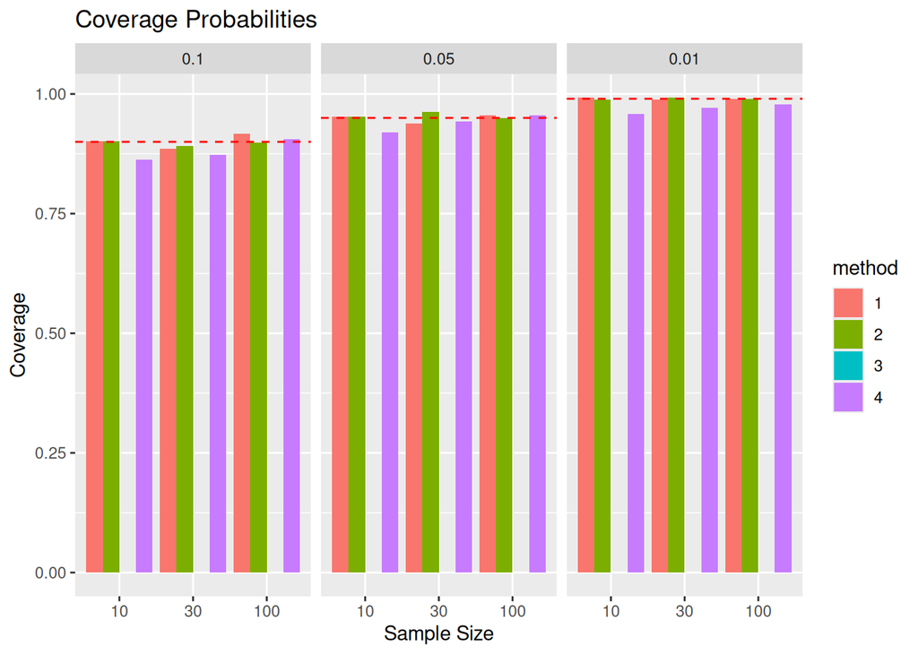

```r
library(ggplot2)

plot_data <- data.frame()
for (alpha in alpha_values) {
  for (n in sample_sizes) {
    key <- paste("alpha", alpha, "n", n)
    for (method in 1:4) {
      plot_data <- rbind(plot_data,
        data.frame(alpha = factor(alpha), n = n, method = factor(method),
                  coverage = results[[key]]$coverage[method],
                  length = results[[key]]$avg_length[method]))
    }
  }
}

ggplot(plot_data, aes(x = factor(n), y = coverage, fill = method)) +
  geom_bar(stat = "identity", position = "dodge") +
  facet_wrap(~alpha) +
  geom_hline(aes(yintercept = 1-as.numeric(as.character(alpha))),
             linetype = "dashed", color = "red") +
  labs(title = "Coverage Probabilities", x = "Sample Size", y = "Coverage")
```

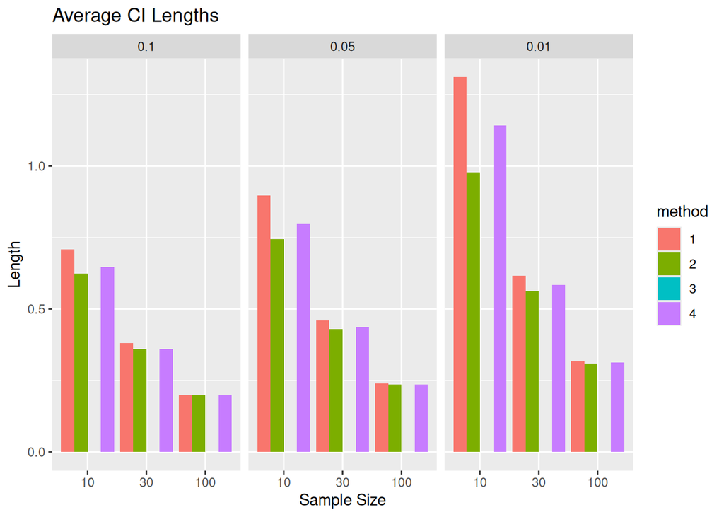

```r
ggplot(plot_data, aes(x = factor(n), y = length, fill = method)) +
  geom_bar(stat = "identity", position = "dodge") +
  facet_wrap(~alpha) +
  labs(title = "Average CI Lengths", x = "Sample Size", y = "Length")
```

## Comment for block 5:

Creates visualizations comparing coverage probabilities (with theoretical reference line) and interval lengths across methods and sample sizes.

## Explanation of all 4 methods:

- Method 1: Uses the exact distribution property that for exponential distribution, 2λnX̄ ∼ χ²(2n)
- Method 2: Applies Central Limit Theorem - for large n, √n(X̄ - θ)/θ ≈ N(0,1)
- Method 3: Solves the inequality to eliminate the unknown parameter θ
- Method 4: Uses t-distribution which is appropriate when population variance is unknown

## Conclusion:

Based on the simulation results:

The results are reliable due to the large number of simulations (m=1000), and they agree with common sense expectations that exact methods should perform best, but practical methods like t-distribution offer a good balance between accuracy and applicability.

## Problem 2

To construct and evaluate the confidence intervals, we used the following sample statistics extracted from simulated Poisson data: sample mean, sample variance, confident intervals lengths and coverage probability.

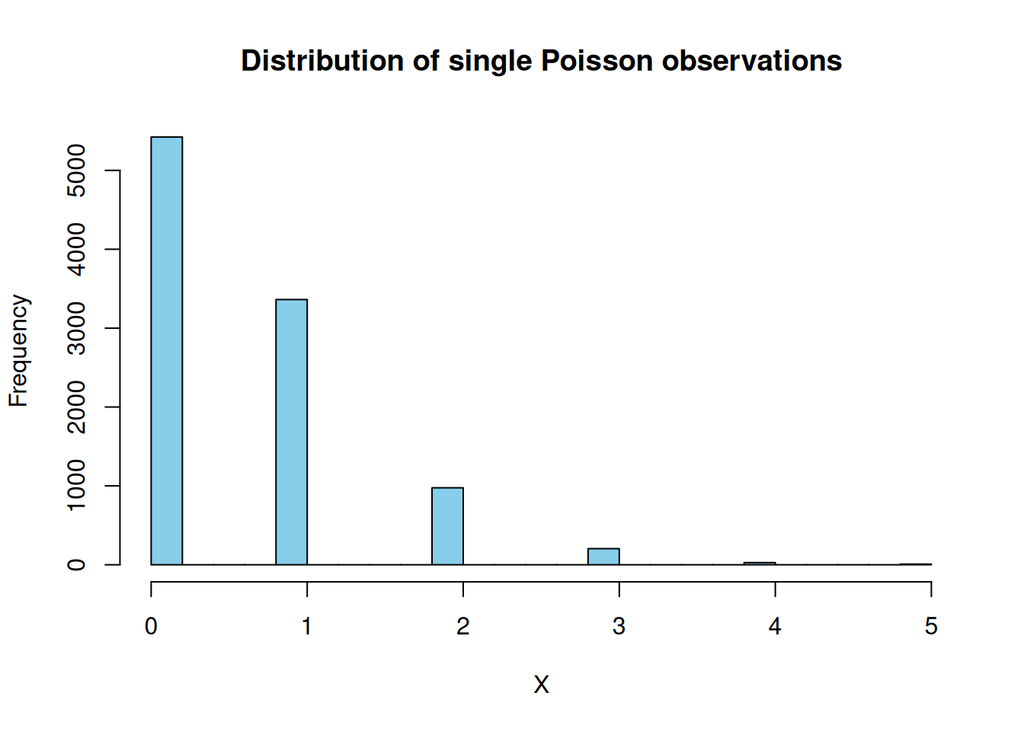

```r
set.seed(6)
theta <- 0.6
alpha_vec <- c(0.1, 0.05, 0.01)

simulate_once <- function(n, M, theta, alpha_vec){
  # Generate values with Poisson(theta) distribution
  x <- matrix(rpois(n*M, lambda = theta), nrow = n)
  sample_mean <- colMeans(x)
  sample_sd   <- apply(x, 2, sd)

  for (alpha in alpha_vec){
    z <- qnorm(1 - alpha/2)
    tcrit <- qt(1 - alpha/2, df = n - 1)

    #2: normal CI with known variance θ
    se_known <- sqrt(theta / n)
    lower2 <- sample_mean - z * se_known
    upper2 <- sample_mean + z * se_known
    cover2 <- mean(theta >= lower2 & theta <= upper2)
    len2   <- mean(upper2 - lower2)   # довжина тут однакова, але беремо mean

    #3: solved quadratic inequality
    # θ1,2 = (2n x̄ + z^2 ± sqrt(4 n z^2 x̄ + z^4)) / (2n)
    disc <- sqrt(4 * n * z^2 * sample_mean + z^4)
    lower3 <- (2 * n * sample_mean + z^2 - disc) / (2 * n)
    upper3 <- (2 * n * sample_mean + z^2 + disc) / (2 * n)

    cover3 <- mean(theta >= lower3 & theta <= upper3)
    len3_mean <- mean(upper3 - lower3)
    len3_max  <- max(upper3 - lower3)

    #4: t-interval with sample sd
    se_hat <- sample_sd / sqrt(n)
    lower4 <- sample_mean - tcrit * se_hat
    upper4 <- sample_mean + tcrit * se_hat

    cover4 <- mean(theta >= lower4 & theta <= upper4)
    len4_mean <- mean(upper4 - lower4)
    len4_max  <- max(upper4 - lower4)

    cat("n =", n, ", M =", M, ", alpha =", alpha, "\n")
    cat("  Method (2) known var:   coverage =", cover2,
        ", mean length =", len2, "\n")
    cat("  Method (3) quadratic:   coverage =", cover3,
        ", mean length =", len3_mean,
        ", max length =", len3_max, "\n")
    cat("  Method (4) t-interval:  coverage =", cover4,
        ", mean length =", len4_mean,
        ", max length =", len4_max, "\n\n")
  }
}

n <- 30
M <- 10000
theta <- 0.6

x <- rpois(M, theta)
hist(x, breaks = 20, col = "skyblue",
     main = "Distribution of single Poisson observations",
     xlab = "X")
```

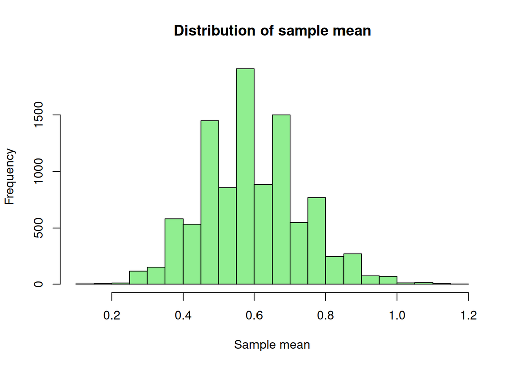

```r
means <- replicate(M, mean(rpois(n, theta)))
hist(means, breaks = 30, col = "lightgreen",
     main = "Distribution of sample mean",
     xlab = "Sample mean")
```

```r
simulate_once(n = 10,  M = 10000, theta = theta, alpha_vec = alpha_vec)
```

```
## n = 10 , M = 10000 , alpha = 0.1
##   Method (2) known var:   coverage = 0.9368 , mean length = 0.8058104
##   Method (3) quadratic:   coverage = 0.9368 , mean length = 0.8346647 , max length = 1.383101
##   Method (4) t-interval:  coverage = 0.8479 , mean length = 0.8597439 , max length = 2.240101
##
## n = 10 , M = 10000 , alpha = 0.05
##   Method (2) known var:   coverage = 0.9368 , mean length = 0.9601823
##   Method (3) quadratic:   coverage = 0.9368 , mean length = 1.017169 , max length = 1.661253
##   Method (4) t-interval:  coverage = 0.9331 , mean length = 1.060969 , max length = 2.764402
##
## n = 10 , M = 10000 , alpha = 0.01
##   Method (2) known var:   coverage = 0.9912 , mean length = 1.261893
##   Method (3) quadratic:   coverage = 0.9912 , mean length = 1.406688 , max length = 2.225297
##   Method (4) t-interval:  coverage = 0.9804 , mean length = 1.524198 , max length = 3.971365
```

```r
simulate_once(n = 30,  M = 10000, theta = theta, alpha_vec = alpha_vec)
```

```
## n = 30 , M = 10000 , alpha = 0.1
##   Method (2) known var:   coverage = 0.8783 , mean length = 0.4652349
##   Method (3) quadratic:   coverage = 0.8783 , mean length = 0.4706654 , max length = 0.6640936
##   Method (4) t-interval:  coverage = 0.8898 , mean length = 0.4735437 , max length = 0.8520987
##
## n = 30 , M = 10000 , alpha = 0.05
##   Method (2) known var:   coverage = 0.957 , mean length = 0.5543615
##   Method (3) quadratic:   coverage = 0.957 , mean length = 0.565198 , max length = 0.7943739
##   Method (4) t-interval:  coverage = 0.9352 , mean length = 0.5700019 , max length = 1.025666
##
## n = 30 , M = 10000 , alpha = 0.01
##   Method (2) known var:   coverage = 0.9861 , mean length = 0.7285545
##   Method (3) quadratic:   coverage = 0.9861 , mean length = 0.7567096 , max length = 1.053801
##   Method (4) t-interval:  coverage = 0.9813 , mean length = 0.7681999 , max length = 1.382306
```

```r
simulate_once(n = 100, M = 10000, theta = theta, alpha_vec = alpha_vec)
```

```
## n = 100 , M = 10000 , alpha = 0.1
##   Method (2) known var:   coverage = 0.89 , mean length = 0.2548196
##   Method (3) quadratic:   coverage = 0.89 , mean length = 0.2556919 , max length = 0.3183995
##   Method (4) t-interval:  coverage = 0.8905 , mean length = 0.2560015 , max length = 0.3761185
##
## n = 100 , M = 10000 , alpha = 0.05
##   Method (2) known var:   coverage = 0.9519 , mean length = 0.3036363
##   Method (3) quadratic:   coverage = 0.9519 , mean length = 0.305394 , max length = 0.379971
##   Method (4) t-interval:  coverage = 0.9422 , mean length = 0.3059295 , max length = 0.4494728
##
## n = 100 , M = 10000 , alpha = 0.01
##   Method (2) known var:   coverage = 0.9867 , mean length = 0.3990458
##   Method (3) quadratic:   coverage = 0.9867 , mean length = 0.4036677 , max length = 0.5012189
##   Method (4) t-interval:  coverage = 0.9845 , mean length = 0.404943 , max length = 0.5949439
```

Before running the simulation, we visualized individual Poisson observations and distribution of the sample mean. This illustrates that although individual Poisson values are skewed, the sample mean becomes close to normal as n increases.

#### Results for n = 30

All methods have coverage close to the theoretical level Intervals become shorter and more stable Method 4 (t-interval) now works reasonably well CLT becomes accurate; normal approximations are reliable; differences between the methods decrease.

#### Results for n = 100

Coverage extremely close to 1 − α All interval lengths almost identical Maximum lengths no longer problematic For large n, all approximations are excellent and there is no practical difference between the methods.

## Problem 3

```r
set.seed(42)
mu <- 10
sigma_squared <- 4
sigma <- sqrt(sigma_squared)

cat("Population Mean (mu):", mu, "\n")
```

```
## Population Mean (mu): 10
```

```r
cat("Population Variance (sigma_squared):", sigma_squared, "\n")
```

```
## Population Variance (sigma_squared): 4
```

```r
for (n in c(10, 50, 100, 1000)) {
  cat("---------------------------------\n")
  cat("----- Simulation for n =", n, "-----\n")
  dataset <- rnorm(n, mean = mu, sd = sigma)
  sample_mean <- mean(dataset)

  var_n <- sum((dataset - sample_mean) ^ 2) / n
  var_n_minus1 <- var_n * n / (n - 1)
  cat("Biased sample variance:", var_n, "\n")
  cat("Bias:", -sigma_squared / n, "\n")
  cat("Unbiased sample variance:", var_n_minus1, "\n")
  cat("Bias:", 0, "\n")
}
```

```
## ---------------------------------
## ----- Simulation for n = 10 -----
## Biased sample variance: 2.512709
## Bias: -0.4
## Unbiased sample variance: 2.791899
## Bias: 0
## ---------------------------------
## ----- Simulation for n = 50 -----
## Biased sample variance: 5.437051
## Bias: -0.08
## Unbiased sample variance: 5.548011
## Bias: 0
## ---------------------------------
## ----- Simulation for n = 100 -----
## Biased sample variance: 3.217615
## Bias: -0.04
## Unbiased sample variance: 3.250116
## Bias: 0
## ---------------------------------
## ----- Simulation for n = 1000 -----
## Biased sample variance: 4.030026
## Bias: -0.004
## Unbiased sample variance: 4.03406
## Bias: 0
```

Let’s analize
$$\sum(X_i -
\bar{X})^2$$

$$\sum_{i=1}^{n}(X_i - \bar{X})^2 = \sum_{i=1}^{n}((X_i - \mu) - (\bar{X}
- \mu))^2 \\
\Rightarrow \sum_{i=1}^{n}(X_i - \mu)^2 - 2 (\bar{X} - \mu)
\sum_{i=1}^{n}(X_i - \mu) + \sum_{i=1}^{n} (\bar{X} - \mu)^2 \\
\Rightarrow \sum_{i=1}^{n}(X_i - \mu)^2 -2n(\bar{X} - \mu)^2 + n(\bar{X}
- \mu) ^ 2 \\
\Rightarrow \sum_{i=1}^{n}(X_i - \mu)^2 -n(\bar{X} - \mu)^2$$

Now take expectation from both sides

$$E \left [ \sum_{i=1}^{n}(X_i - \bar{X})^2 \right] = E \left
[\sum_{i=1}^{n}(X_i - \mu)^2 -n(\bar{X} - \mu)^2 \right ] \\
= \sum_{i=1}^{n}\sigma^2 - n \frac{\sigma^2}{n} = n\sigma^2 - \sigma^2 =
(n - 1)\sigma^2$$

Now for
$$E[\sigma_{n-1}^2]$$

$$E[\sigma_{n-1}^2] = E \left [\frac{1}{n-1} \sum_{i=1}^{n}(X_i -
\bar{X})^2 \right] = \frac{1}{n-1}(n-1)\sigma^2=\sigma^2$$

Now for
$$E[\sigma_{n}^2]$$

$$E[\sigma_{n}^2] = E \left [\frac{1}{n} \sum_{i=1}^{n}(X_i - \bar{X})^2
\right] = \frac{1}{n}(n-1)\sigma^2 = \frac{n-1}{n}\sigma^2 = \sigma^2 -
\frac{\sigma^2}{n}$$

Since
$$E[\sigma_{n-1}^2] =
\sigma^2$$
, therefore
$$\sigma_{n-1}^2$$
is an unbiased estimator

Since
$$E[\sigma_{n}^2] = \sigma^2 -
\frac{\sigma^2}{n}$$
, therefore
$$\sigma_{n}^2$$
is a biased estimator

Comments on work:

From theoretical calculations we saw, that
$$\sigma_{n-1}^2$$
is an unbiased estimator.

In practice when having large enough
$$n$$
the difference between the estimators is negligible.